# Homework 6

Yiming Wang

Due @ 5pm on December 1, 2017

**Part 1.** You will implement matrix completion algorithms. We first set some notation: $\M{X} \in \Real^{n \times p}$ and $\Omega \subset \{1, \ldots, n\} \times \{1, \ldots, p\}$. We seek the matrix $\M{U} \in \Real^{n \times p}$ that minimizes the following objective function
$$\ell(\M{U}) = \frac{1}{2}\lVert \mathcal{P}_\Omega(\M{X}) - \mathcal{P}_\Omega(\M{U}) \rVert_{\text{F}}^2 + \lambda \lVert \M{U} \rVert_*,$$
where $\lVert \M{U} \rVert_*$ is the nuclear norm of $\M{U}, \lambda$ is a non-negative regularization parameter. The projection operator $\mathcal{P}_\Omega$ acts as a mask

$$[\mathcal{P}_\Omega(\M{Z})]_{ij} = \begin{cases}
\ME{z}{ij} & \text{if $(i,j) \in \Omega$} \\
0 & \text{otherwise.}
\end{cases}$$

1. Prove that the function $\ell(\M{U})$ is convex.

By triangle inequality, $\lVert \mathcal{P}_\Omega(\M{X}) - \mathcal{P}_\Omega(\M{U}) \rVert_{\text{F}}^2$ and $\lVert \M{U} \rVert_*$ are convex. Since $f(x)=\frac{1}{2}x^2$ and $g(x)=\lambda x$ are nondecreasing, $\ell(\M{U})$ is convex.

2. Derive the gradient of $\frac{1}{2}\lVert \mathcal{P}_\Omega(\M{X}) - \mathcal{P}_\Omega(\M{U}) \rVert_{\text{F}}^2$ and prove that it is a 1-Lipschitz mapping.

And we have $\lVert \nabla g(\M{U})-\nabla g(\M{Q})\rVert_2=\lVert\mathcal{P}_\Omega(\M{X}) - \mathcal{P}_\Omega(\M{U})\rVert_2=\underset{\lVert \V{x}\rVert=1 }{sup}\lVert\mathcal{P}_\Omega(\M{U}-\M{Q})\V{x}\rVert_2=\underset{\lVert \V{x}\rVert=1 }{sup}(\V{x}^T\mathcal{P}_\Omega(\M{U-Q})^T\mathcal{P}_\Omega(\M{U-Q})\V{x})\leq\underset{\lVert \V{x}\rVert=1 }{sup}(\V{x}^T(\M{U-Q})^T(\M{U-Q})\V{x})=\lVert\M{U-Q}\rVert_2$

Therefore $\lVert \nabla g(\M{U})-\nabla g(\M{Q})\rVert_2\leq\lVert\M{U}-\M{Q}\rVert_2$

3. What is the computational complexity of computing a proximal-gradient step:

First,to get $\nabla \left\{\frac{1}{2}\lVert \mathcal{P}_\Omega(\M{X}) - \mathcal{P}_\Omega(\M{U}) \rVert_{\text{F}}^2 \right\} = \mathcal{P}_\Omega(\M{U}) - \mathcal{P}_\Omega(\M{X})$, it takes $\mathcal{O}(np)$ to calculate the $\M{Y} = \M{U} - t \nabla \left\{\frac{1}{2}\lVert \mathcal{P}_\Omega(\M{X}) - \mathcal{P}_\Omega(\M{U}) \rVert_{\text{F}}^2 \right\}$. Then, it takes $\mathcal{O}(min\{np^2,n^2p\})$ to calculate the SVD of $\M{Y}$. Then, it takes $\mathcal{O}(min\{n, p\})$ to calculate the soft-thresholding of the singular values. Then, it takes $\mathcal{O}(min\{np^2,n^2p\})$ to get back to the new iteration of $\M{U}$ through SVD. Therefore, in total, the computational complexity is $\mathcal{O}(min\{np^2,n^2p\})$.

4. Prove that for all $\lambda \geq \lambda_{\max} = \lVert \mathcal{P}_{\Omega}(\M{X}) \rVert_2$, the all zeros matrix is a global minimizer of $\ell(\M{U})$. You may use the fact that $\partial \lVert \M{0} \rVert_* = \{ \M{V} : \lVert \M{V} \rVert_2 \leq 1\}$.

If $\frac{1}{\lambda} \lVert\mathcal{P}_{\Omega}(\M{X}) \rVert_2 \leq 1$, since it is equivalent to $\frac{1}{\lambda}\mathcal{P}_{\Omega}(\M{X})\in \{ \M{V} : \lVert \M{V} \rVert_2 \leq 1\}$ through writing it as the form of set, we have $-\nabla g( \M{0})\in \partial \lambda \lVert \M{0} \rVert_*$. The former statement is also equivalent to $0 \in \partial \ell(\M{0})$ since $\partial \lVert \M{0} \rVert_* = \{ \M{V} : \lVert \M{V} \rVert_2 \leq 1\}$ and therefore we have that all zeros matrix is a global minimizer of $\ell(\M{U})$.

5. What is the computational complexity of a single soft-impute update? How does this compare to the computational complexity of a single proximal-gradient step?

First, it taks $\mathcal{np}$ flops to calculate the $\M{Y}=\mathcal{P}_{\Omega^c}(\M{U}^{(k-1)})+\mathcal{P}_\Omega(\M{X})$. Then, the rest steps take same flops as the steps in Q3 since they have the same manipulation on the matrix. Therefore, in total, the computational complexity is $\mathcal{O}(min\{np^2,n^2p\})$, which is the same as proximal gradient step. The reason for this equivalence is that the SVD steps are commonly used in both methods and therefore overwhelms the computational complexity.

**Part 2.** MM algorithm and proximal gradient algorithm for matrix completion.

Please complete the following steps.

**Step 1:** Write a function “softthreshold” that implements the softthreshold mapping.

```r
#' Softthreshold operator
#'
#' @param x input vector
#' @param lambda threshold
#' @export
#' @examples
#' softthreshold(seq(-10, 10, length.out=10), 1)
softthreshold <- function(x, lambda) {
  temp=abs(x)-lambda;
  return(ifelse(temp>0,temp,-temp)*sign(x));
}
```

**Step 2:** Write a function “prox_nuc” that computes the proximal mapping of $\gamma\lVert \cdot \rVert_*$.

```r
#' Proximal mapping of the scaled nuclear norm
#'
#' @param X input matrix
#' @param gamma scale parameter
#' @export
#' @examples
#' set.seed(12345)
#' n <- 10; p <- 20
#' X <- matrix(rnorm(n*p), n, p)
#' Y <- prox_nuc(X, 1)
prox_nuc <- function(X, gamma) {
 decomposition=svd(X);
 new_d=softthreshold(decomposition$d,gamma);
 X_map=decomposition$u%*%diag(new_d)%*%t(decomposition$v)
 return(X_map);
}
```

**Step 3:** Write a function “project_omega” that projects a matrix onto an observation index set $\Omega$. Omega consists of indices that are in column major order.

```r
#' Project matrix onto observed index set
#'
#' @param X input matrix
#' @param Omega index set
#' @export
#' @examples
#' set.seed(12345)
#' n <- 10; p <- 20
#' X <- matrix(rnorm(n*p), n, p)
#' numel <- n*p
#' Omega <- sample(1:numel, floor(0.5*numel), replace=FALSE)
#' PX <- project_omega(X, Omega)
project_omega <- function(X, Omega) {
  p=ncol(X);n=nrow(X);
  res=Omega%%n;int=Omega%/%n;
  row=ifelse(res==0,n,res);
  col=ifelse(res==0,int,int+1);
  Result=matrix(0,nrow(X),ncol(X));
  for(i in 1:length(Omega))
  Result[row[i],col[i]]=X[row[i],col[i]];
  return(Result);
}
```

**Step 4:** Write a function “prox_step” that computes a single proximal gradient step.

```r
#' Proximal-Gradient Step
#'
#' @param X input matrix
#' @param U current guess
#' @param Omega index set
#' @param lambda regularization parameter
#' @param t step size
#' @export
#' @examples
#' set.seed(12345)
#' n <- 10; p <- 20
#' X <- matrix(rnorm(n*p), n, p)
#' numel <- n*p
#' Omega <- sample(1:numel, floor(0.5*numel), replace=FALSE)
#' U <- matrix(rnorm(n*p), n, p)
#' U[Omega] <- X[Omega]
#' lambda <- 1
#' t <- 1
#' U1 <- prox_step(X, U, Omega, lambda, t)
prox_step <- function(X, U, Omega, lambda, t) {
  #X_half=X-(project_omega(X,Omega)-project_omega(U,Omega))*t;
  X_half=U-t*project_omega(U-X,Omega);
  out=prox_nuc(X_half,lambda)
  return(out);
}
```

**Step 5:** Write a function “matrix_completion_loss” that computes the objective function $\ell(\M{U})$.

```r
#' Matrix Completion Loss
#'
#' @param X input matrix
#' @param U current guess
#' @param Omega index set
#' @param lambda regularization parameter
#' @export
#' @examples
#' set.seed(12345)
#' n <- 10; p <- 20
#' X <- matrix(rnorm(n*p), n, p)
#' numel <- n*p
#' Omega <- sample(1:numel, floor(0.5*numel), replace=FALSE)
#' U <- matrix(rnorm(n*p), n, p)
#' U[Omega] <- X[Omega]
#' lambda <- 1
#' matrix_completion_loss(X, U, Omega, lambda)
matrix_completion_loss <- function(X, U, Omega, lambda) {
  diff_matrix=project_omega(X,Omega)-project_omega(U,Omega);
  nuclear_norm=sum(svd(U)$d);
  return((norm(diff_matrix,type="F"))^2*0.5+lambda*nuclear_norm)
}
```

**Step 6:** Write a function “prox_grad” that performs proximal gradient descent. Use the Lipschitz constant you derived above to guide your choice of the step size. Note that convergence is still guaranteed with a fixed step size if the step-size is less than twice the reciprical of the Lipschitz constant. Terminate the algorithm once the relative change in the objective falls below a tolerance or if a maximum number of iterations is achieved.

```r
#' Proximal Gradient Descent
#'
#' @param X input matrix
#' @param U current guess
#' @param Omega index set
#' @param lambda regularization parameter
#' @param t step-size parameter
#' @param max_iter maximum number of iterations
#' @param tol convergence tolerance
#' @export
#' @examples
#' set.seed(12345)
#' n <- 10; p <- 20
#' X <- matrix(rnorm(n*p), n, p)
#' numel <- n*p
#' Omega <- sample(1:numel, floor(0.5*numel), replace=FALSE)
#' U <- matrix(rnorm(n*p), n, p)
#' U[Omega] <- X[Omega]
#' lambda <- 1
#' pg_sol <- prox_grad(X, U, Omega, lambda,1)
prox_grad <- function(X, U, Omega, lambda, t, max_iter=1e2, tol=1e-3) {
  times=0;
  U_new=prox_step(X,U,Omega,lambda,t);
  obj_new=matrix_completion_loss(X,U_new,Omega,lambda);
  obj=obj_new;
  norm_X_F=norm(X,type="F");
  relative_change_function_value=tol+1;
  while(times<max_iter&(relative_change_function_value>tol)){#|(obj_new<obj)
    times=times+1;
    obj=obj_new;
    U_new=prox_step(X,U_new,Omega,lambda,t);
    obj_new=matrix_completion_loss(X,U_new,Omega,lambda);
    #print(paste0(times," loss: ",obj_new,"change",relative_change_function_value));#
    relative_change_function_value=obj/obj_new-1;
    relative_change_iterate_value=norm(U_new-X,type="F")^2/norm_X_F^2;
  }
  return(list(iterate_value=U_new,
              objective_function_value=matrix_completion_loss(X,U_new,Omega,lambda),
              relative_change_function_value=relative_change_function_value,
              relative_change_iterate_value=relative_change_iterate_value));

}
```

Your function should return

- The final iterate value
- The objective function values
- The relative change in the function values
- The relative change in the iterate values

**Step 7:** Write a function “soft_impute” that performs soft-impute algorithm. Terminate the algorithm once the relative change in the objective falls below a tolerance or if a maximum number of iterations is achieved.

```r
#' Soft-Impute Algorithm
#'
#' @param X input matrix
#' @param U current guess
#' @param Omega index set
#' @param lambda regularization parameter
#' @param max_iter maximum number of iterations
#' @param tol convergence tolerance
#' @export
#' @examples
#' set.seed(12345)
#' n <- 10; p <- 20
#' X <- matrix(rnorm(n*p), n, p)
#' numel <- n*p
#' Omega <- sample(1:numel, floor(0.5*numel), replace=FALSE)
#' U <- matrix(rnorm(n*p), n, p)
#' U[Omega] <- X[Omega]
#' lambda <- 1
#' si_sol <- soft_impute(X, U, Omega, lambda)
soft_impute <- function(X, U, Omega, lambda, max_iter=1e2, tol=1e-3) {
  times=0;n=nrow(X);p=ncol(X);total_seq=1:(n*p);
  U_new=U;
  Omega_compliment=total_seq[-Omega];
  obj_new=matrix_completion_loss(X,U_new,Omega,lambda);
  norm_X_F=norm(X,"F");
  relative_change_function_value=1;
  relative_change_iterate_value=1;
  obj=obj_new;

  while(times<max_iter&(relative_change_function_value>tol|obj_new>obj)){
    times=times+1;
    obj=obj_new;#renew
    Y_matrix=project_omega(X,Omega)+project_omega(U_new,Omega_compliment);
    decomposition=svd(Y_matrix);
    new_d=softthreshold(decomposition$d,lambda);
    U_new=decomposition$u%*%diag(new_d)%*%t(decomposition$v);
    obj_new=matrix_completion_loss(X,U_new,Omega,lambda);
    #loss=matrix_completion_loss(X,U_new,Omega,lambda);
    relative_change_function_value=obj/obj_new-1;
    relative_change_iterate_value=norm(U_new-X,type="F")^2/norm_X_F^2;
    #print(paste0(times," function ",relative_change_function_value," change_function ",relative_change_function_value));
  }
  return(list(iterate_value=U_new,
              objective_function_value=matrix_completion_loss(X,U_new,Omega,lambda),
              relative_change_function_value=relative_change_function_value,
              relative__change_iterate_value=relative_change_iterate_value));
}
```

Your function should return

- The final iterate value
- The objective function values
- The relative change in the function values
- The relative change in the iterate values

**Step 8:** Apply your two algorithms on images A and B. Use 5 different values of $\lambda$ equally spaced on the logarithmic scale between $10^{-6}$ and $\lambda_{\max}$. Plot a sequence of images corresponding to your recovered matrix estimates. Plot the images in 4-level grayscale. You might find the `gray` function useful.

Use prox_grad for image A

[figure not shown]

```r
imageA <- as.matrix(read.table('imageA.csv', sep=",", header=FALSE))
image(imageA, col=gray(0:3/3))
```

[figure not shown]

```r
#find Omega
Omega=which(is.na(imageA)==FALSE)#observed
Not_Omega=which(is.na(imageA))#not observed

n <- nrow(imageA); p <- ncol(imageA)
UA <- matrix(rnorm(n*p), n, p)
UA[Omega] <- imageA[Omega]

lambda=exp(seq(from=10^(-6),to=5,length.out = 5))
XA=imageA
XA[Not_Omega]=0

image(prox_grad(XA, UA, Omega, lambda[1], t=1, max_iter=1e2, tol=1e-3)$iterate_value,col=gray(0:4/4))
```

[figure not shown]

```r
image(prox_grad(XA, UA, Omega, lambda[2], t=1, max_iter=1e2, tol=1e-3)$iterate_value,col=gray(0:4/4))
```

[figure not shown]

```r
image(prox_grad(XA, UA, Omega, lambda[3], t=1, max_iter=1e2, tol=1e-3)$iterate_value,col=gray(0:4/4))
```

[figure not shown]

```r
image(prox_grad(XA, UA, Omega, lambda[4], t=1, max_iter=1e2, tol=1e-3)$iterate_value,col=gray(0:4/4))
```

[figure not shown]

```r
image(prox_grad(XA, UA, Omega, lambda[5], t=1, max_iter=1e2, tol=1e-3)$iterate_value,col=gray(0:4/4))
```

Use prox_grad for image B

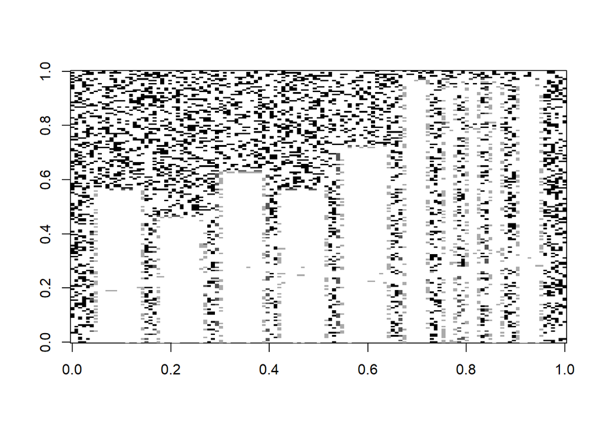

```r
imageB <- as.matrix(read.table('imageB.csv', sep=",", header=FALSE))
image(imageB, col=gray(0:3/3))
```

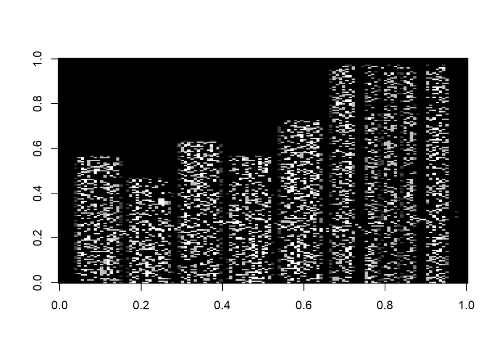

```r
#find Omega
Omega=which(is.na(imageB)==FALSE)#observed
Not_Omega=which(is.na(imageB))#not observed

n <- nrow(imageB); p <- ncol(imageB)
UB <- matrix(rnorm(n*p), n, p)
UB[Omega] <- imageB[Omega]
#
lambda=exp(seq(from=10^(-6),to=5,length.out = 5))
XB=imageB
XB[Not_Omega]=0

image(prox_grad(XB, UB, Omega, lambda[1], t=1, max_iter=1e2, tol=1e-3)$iterate_value,col=gray(0:4/4))
```

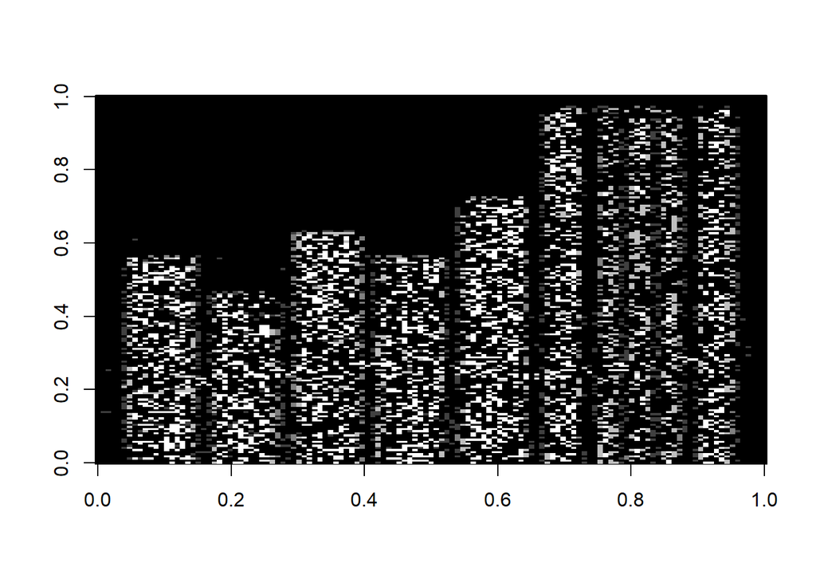

```r
image(prox_grad(XB, UB, Omega, lambda[2], t=1, max_iter=1e2, tol=1e-3)$iterate_value,col=gray(0:4/4))
```

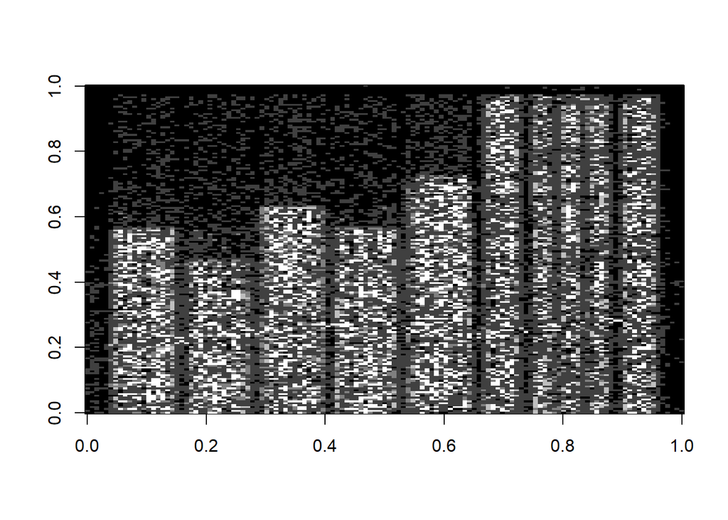

```r
image(prox_grad(XB, UB, Omega, lambda[3], t=1, max_iter=1e2, tol=1e-3)$iterate_value,col=gray(0:4/4))
```

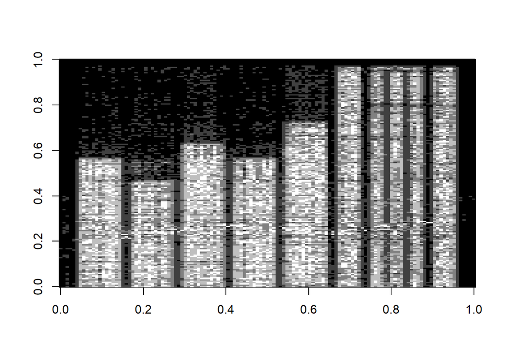

```r
image(prox_grad(XB, UB, Omega, lambda[4], t=1, max_iter=1e2, tol=1e-3)$iterate_value,col=gray(0:4/4))
```

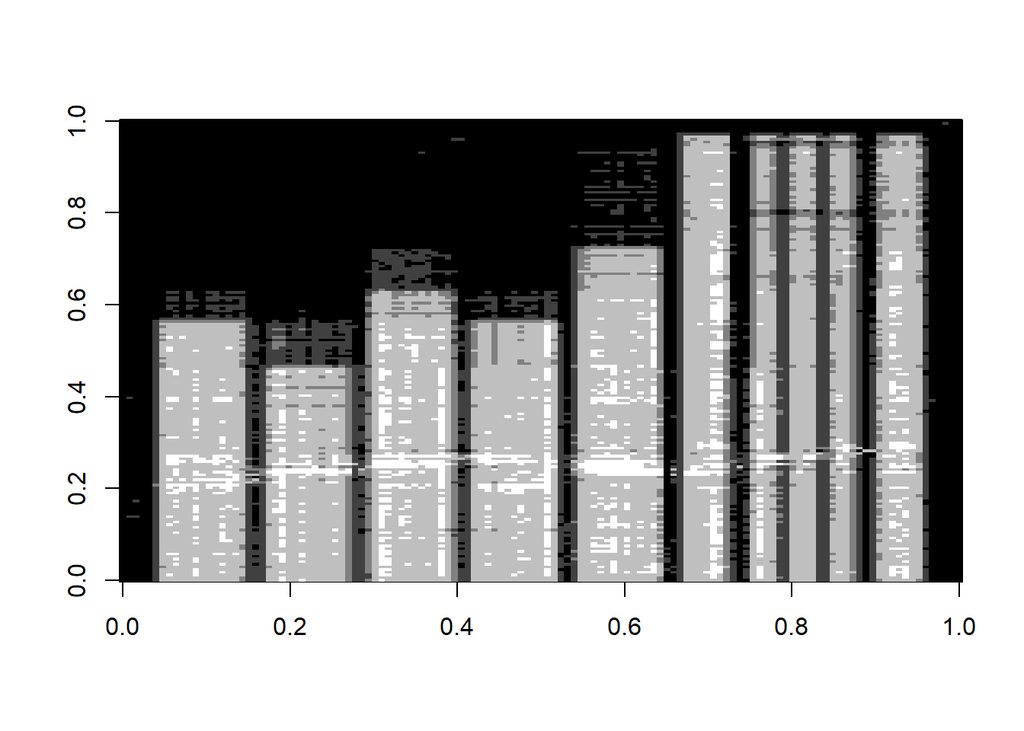

```r
image(prox_grad(XB, UB, Omega, lambda[5], t=1, max_iter=1e2, tol=1e-3)$iterate_value,col=gray(0:4/4))
```

Use soft_impute for image A

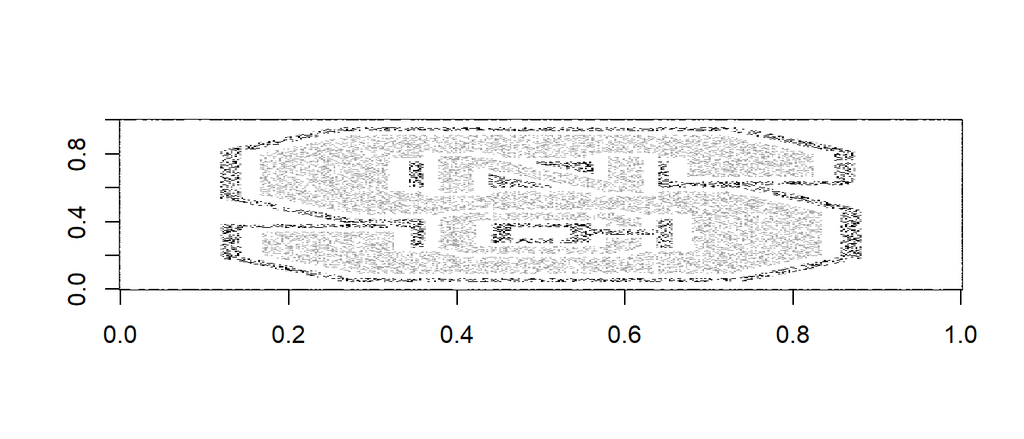

```r
imageA <- as.matrix(read.table('imageA.csv', sep=",", header=FALSE))
image(imageA, col=gray(0:3/3))
```

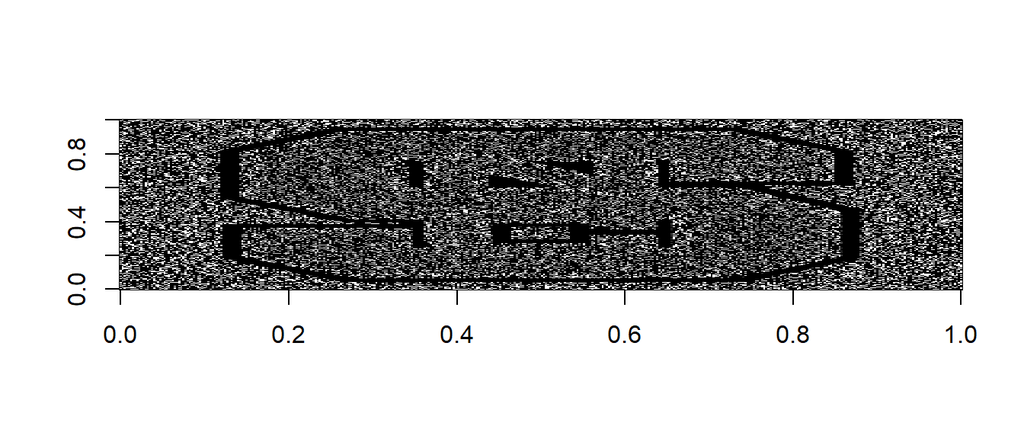

```r
#find Omega
Omega=which(is.na(imageA)==FALSE)#observed
Not_Omega=which(is.na(imageA))#not observed

n <- nrow(imageA); p <- ncol(imageA)
UA <- matrix(rnorm(n*p), n, p)
UA[Omega] <- imageA[Omega]

lambda=exp(seq(from=10^(-6),to=5,length.out = 5))
XA=imageA
XA[Not_Omega]=0

image(soft_impute(XA, UA, Omega, lambda[1])$iterate_value,col=gray(0:4/4))
```

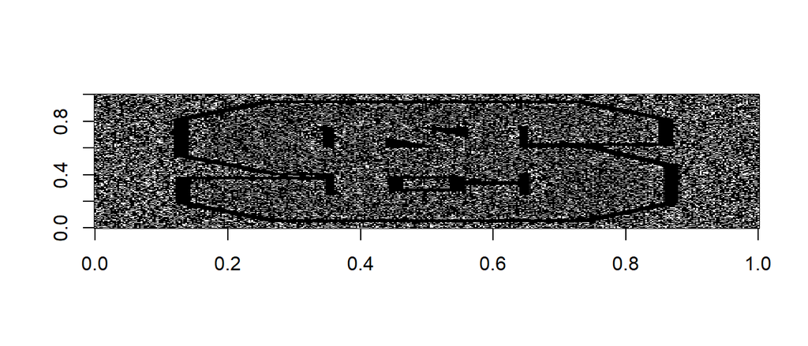

```r
image(soft_impute(XA, UA, Omega, lambda[2])$iterate_value,col=gray(0:4/4))
```

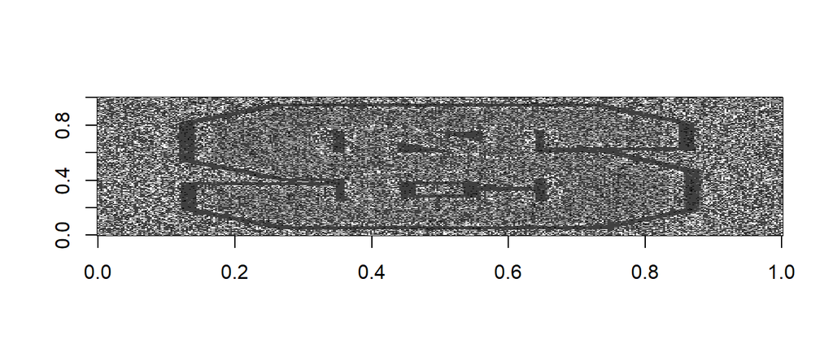

```r
image(soft_impute(XA, UA, Omega, lambda[3])$iterate_value,col=gray(0:4/4))
```

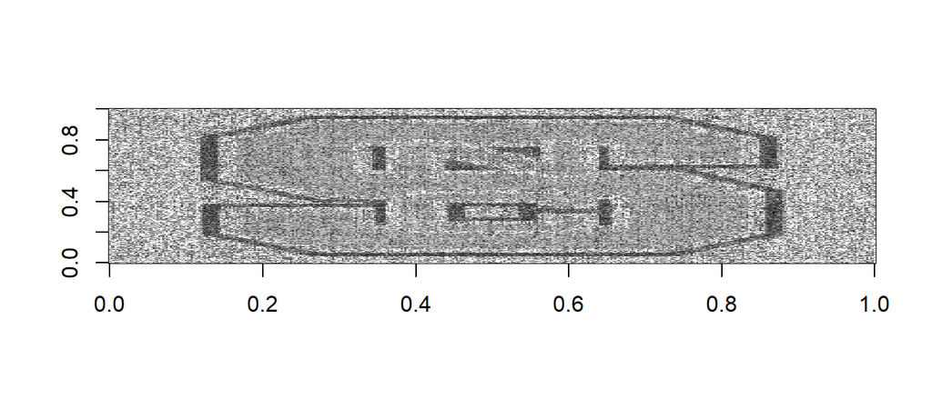

```r
image(soft_impute(XA, UA, Omega, lambda[4])$iterate_value,col=gray(0:4/4))
```

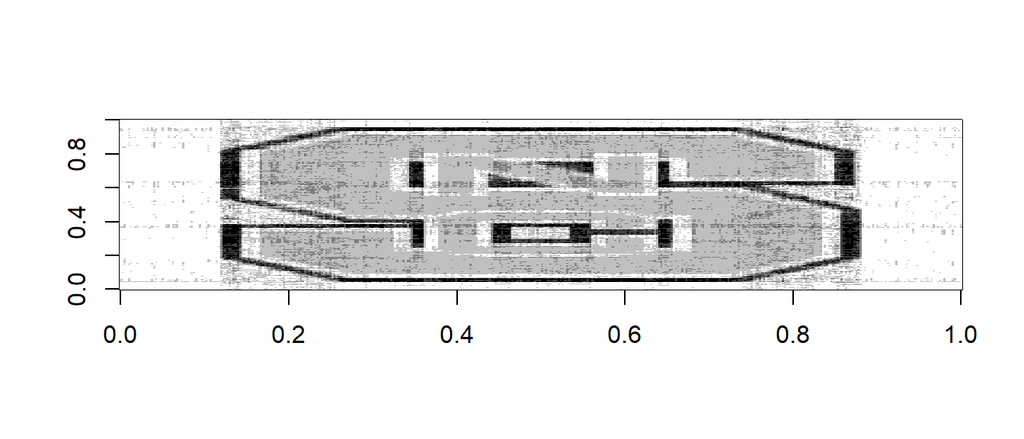

```r
image(soft_impute(XA, UA, Omega, lambda[5])$iterate_value,col=gray(0:4/4))
```

Use soft_impute for image B

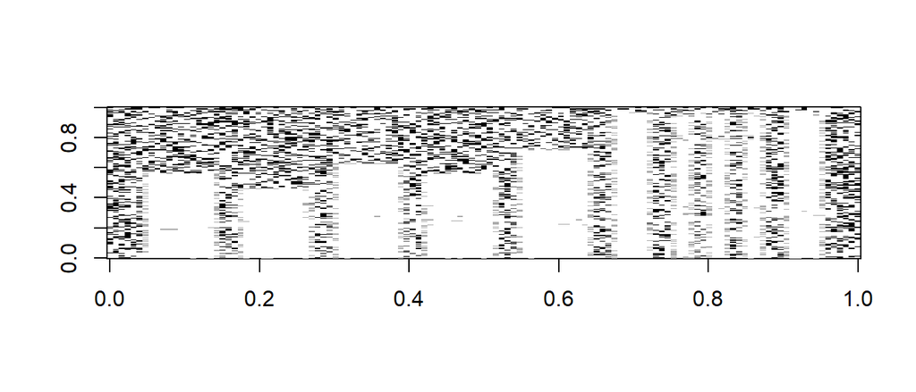

```r
imageB <- as.matrix(read.table('imageB.csv', sep=",", header=FALSE))
image(imageB, col=gray(0:3/3))
```

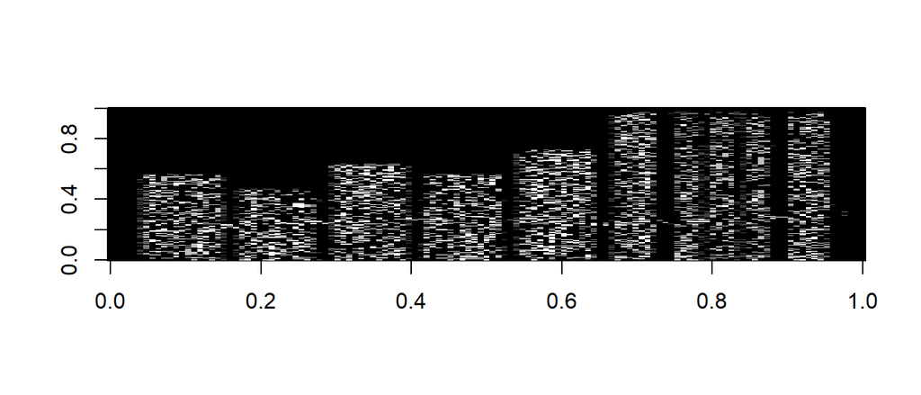

```r
#find Omega
Omega=which(is.na(imageB)==FALSE)#observed
Not_Omega=which(is.na(imageB))#not observed

n <- nrow(imageB); p <- ncol(imageB)
UB <- matrix(rnorm(n*p), n, p)
UB[Omega] <- imageB[Omega]
#
lambda=exp(seq(from=10^(-6),to=5,length.out = 5))
XB=imageB
XB[Not_Omega]=0

image(soft_impute(XB, UB, Omega, lambda[1])$iterate_value,col=gray(0:4/4))
```

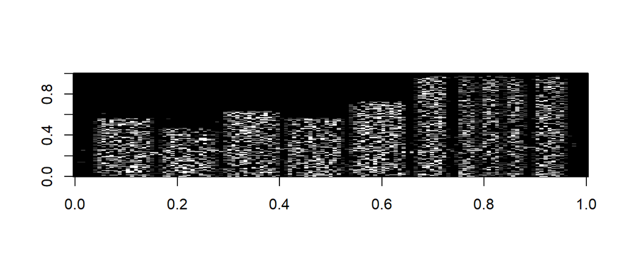

```r
image(soft_impute(XB, UB, Omega, lambda[2])$iterate_value,col=gray(0:4/4))
```

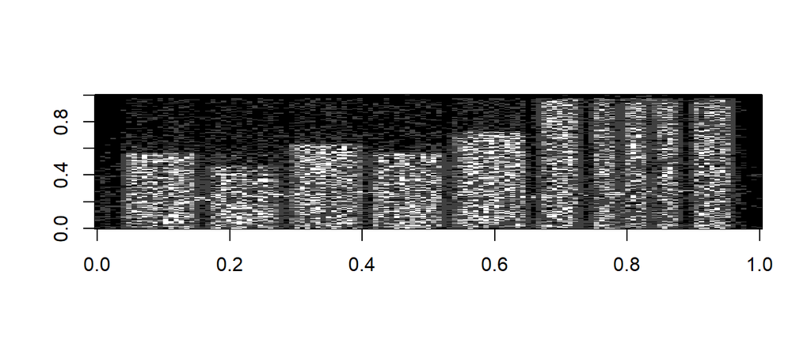

```r
image(soft_impute(XB, UB, Omega, lambda[3])$iterate_value,col=gray(0:4/4))
```

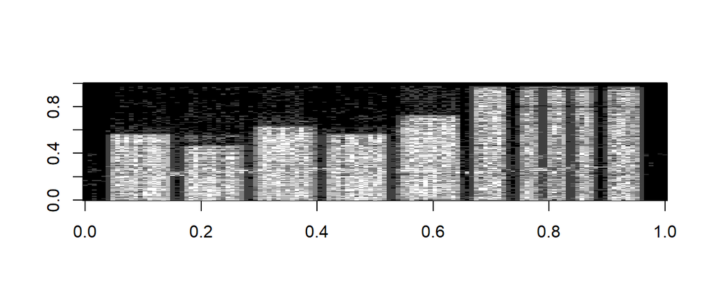

```r
image(soft_impute(XB, UB, Omega, lambda[4])$iterate_value,col=gray(0:4/4))
```

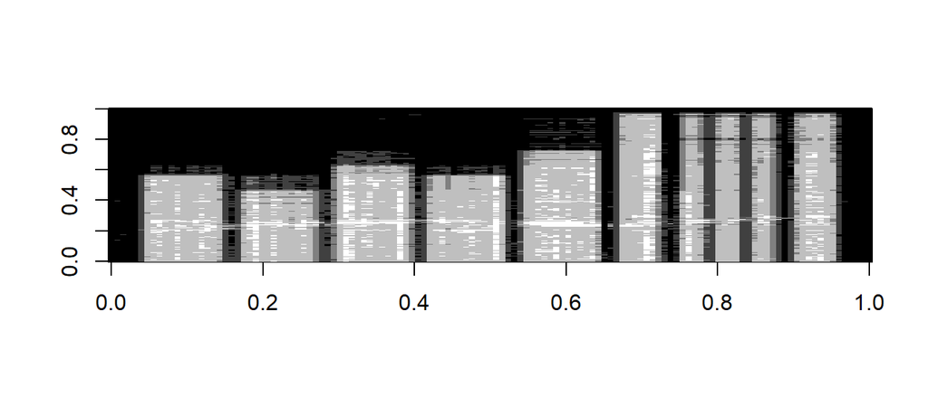

```r
image(soft_impute(XB, UB, Omega, lambda[5])$iterate_value,col=gray(0:4/4))
```